# Music and mood

Akriti Acharya

2026-09-8

```r
library(tidyverse)
```

# Introduction:

For my project, I’m using the mxmh survey dataset, which has 736 responses and 33 columns. The data includes things like age, favorite genre, hours spent listening to music each day, and whether people listen while working. It also has mental health information such as anxiety, depression, insomnia, and OCD scores, plus whether people feel music improves, worsens, or has no effect on their mood.

This dataset is useful because it connects music habits with mental health and focus. That means I can look at questions like: do certain genres (like lo‑fi,pop, or rap) relate to lower anxiety? Does listening while working help people focus? Or does the tempo (BPM) of music make a difference in how people feel?

#Background

Music and Emotional Regulation

Music engages brain reward pathways, releasing dopamine and reducing stress and anxiety. As the Healthline article explains, listening to preferred music can boost motivation and pleasure, though certain genres may reinforce depressive moods when listeners are already vulnerable. This dual effect highlights the complexity of music’s role in mental health.

Cognition, Identity, and Clinical Applications

The Home Monitor on Psychology article emphasizes music’s role in cognition and identity. Research shows that self‑selected music strongly activates reward circuits tied to personal values, explaining its deep emotional impact. Clinical applications include neurologic music therapy, which has been used to restore speech and movement in patients with brain injuries. Studies also show music can regulate memory, imagination, and cultural identity, making it a powerful tool for psychological health.

# Looking at the data

```r
mxmh_survey_results <- read_csv("mxmh_survey_results.csv")
# Looking at the first few rows

head(mxmh_survey_results)
```

```
## # A tibble: 6 × 33
##   Timestamp           Age Primary streaming se…¹ `Hours per day` `While working`
##   <chr>             <dbl> <chr>                            <dbl> <chr>
## 1 8/27/2022 19:29:…    18 Spotify                            3   Yes
## 2 8/27/2022 19:57:…    63 Pandora                            1.5 Yes
## 3 8/27/2022 21:28:…    18 Spotify                            4   No
## 4 8/27/2022 21:40:…    61 YouTube Music                      2.5 Yes
## 5 8/27/2022 21:54:…    18 Spotify                            4   Yes
## 6 8/27/2022 21:56:…    18 Spotify                            5   Yes
## # ℹ abbreviated name: ¹`Primary streaming service`
## # ℹ 28 more variables: Instrumentalist <chr>, Composer <chr>,
## #   `Fav genre` <chr>, Exploratory <chr>, `Foreign languages` <chr>, BPM <dbl>,
## #   `Frequency [Classical]` <chr>, `Frequency [Country]` <chr>,
## #   `Frequency [EDM]` <chr>, `Frequency [Folk]` <chr>,
## #   `Frequency [Gospel]` <chr>, `Frequency [Hip hop]` <chr>,
## #   `Frequency [Jazz]` <chr>, `Frequency [K pop]` <chr>, …
```

```r
# Column names
names(mxmh_survey_results)
```

```
##  [1] "Timestamp"                    "Age"
##  [3] "Primary streaming service"    "Hours per day"
##  [5] "While working"                "Instrumentalist"
##  [7] "Composer"                     "Fav genre"
##  [9] "Exploratory"                  "Foreign languages"
## [11] "BPM"                          "Frequency [Classical]"
## [13] "Frequency [Country]"          "Frequency [EDM]"
## [15] "Frequency [Folk]"             "Frequency [Gospel]"
## [17] "Frequency [Hip hop]"          "Frequency [Jazz]"
## [19] "Frequency [K pop]"            "Frequency [Latin]"
## [21] "Frequency [Lofi]"             "Frequency [Metal]"
## [23] "Frequency [Pop]"              "Frequency [R&B]"
## [25] "Frequency [Rap]"              "Frequency [Rock]"
## [27] "Frequency [Video game music]" "Anxiety"
## [29] "Depression"                   "Insomnia"
## [31] "OCD"                          "Music effects"
## [33] "Permissions"
```

```r
# Summary statistics
summary(mxmh_survey_results)
```

```
##   Timestamp              Age        Primary streaming service Hours per day
##  Length:736         Min.   :10.00   Length:736                Min.   : 0.000
##  Class :character   1st Qu.:18.00   Class :character          1st Qu.: 2.000
##  Mode  :character   Median :21.00   Mode  :character          Median : 3.000
##                     Mean   :25.21                             Mean   : 3.573
##                     3rd Qu.:28.00                             3rd Qu.: 5.000
##                     Max.   :89.00                             Max.   :24.000
##                     NA's   :1
##  While working      Instrumentalist      Composer          Fav genre
##  Length:736         Length:736         Length:736         Length:736
##  Class :character   Class :character   Class :character   Class :character
##  Mode  :character   Mode  :character   Mode  :character   Mode  :character
##
##
##
##
##  Exploratory        Foreign languages       BPM           Frequency [Classical]
##  Length:736         Length:736         Min.   :0.00e+00   Length:736
##  Class :character   Class :character   1st Qu.:1.00e+02   Class :character
##  Mode  :character   Mode  :character   Median :1.20e+02   Mode  :character
##                                        Mean   :1.59e+06
##                                        3rd Qu.:1.44e+02
##                                        Max.   :1.00e+09
##                                        NA's   :107
##  Frequency [Country] Frequency [EDM]    Frequency [Folk]   Frequency [Gospel]
##  Length:736          Length:736         Length:736         Length:736
##  Class :character    Class :character   Class :character   Class :character
##  Mode  :character    Mode  :character   Mode  :character   Mode  :character
##
##
##
##
##  Frequency [Hip hop] Frequency [Jazz]   Frequency [K pop]  Frequency [Latin]
##  Length:736          Length:736         Length:736         Length:736
##  Class :character    Class :character   Class :character   Class :character
##  Mode  :character    Mode  :character   Mode  :character   Mode  :character
##
##
##
##
```

[output cut: 17 more lines]

```
##  Min.   : 0.000   Min.   : 0.000   Min.   : 0.000   Min.   : 0.000
##  1st Qu.: 4.000   1st Qu.: 2.000   1st Qu.: 1.000   1st Qu.: 0.000
##  Median : 6.000   Median : 5.000   Median : 3.000   Median : 2.000
##  Mean   : 5.838   Mean   : 4.796   Mean   : 3.738   Mean   : 2.637
##  3rd Qu.: 8.000   3rd Qu.: 7.000   3rd Qu.: 6.000   3rd Qu.: 5.000
##  Max.   :10.000   Max.   :10.000   Max.   :10.000   Max.   :10.000
##
##  Music effects      Permissions
##  Length:736         Length:736
##  Class :character   Class :character
##  Mode  :character   Mode  :character
##
##
##
##
```

```r
# Genre counts
table(mxmh_survey_results$`Fav genre`)
```

```
##
##        Classical          Country              EDM             Folk
##               53               25               37               30
##           Gospel          Hip hop             Jazz            K pop
##                6               35               20               26
##            Latin             Lofi            Metal              Pop
##                3               10               88              114
##              R&B              Rap             Rock Video game music
##               35               22              188               44
```

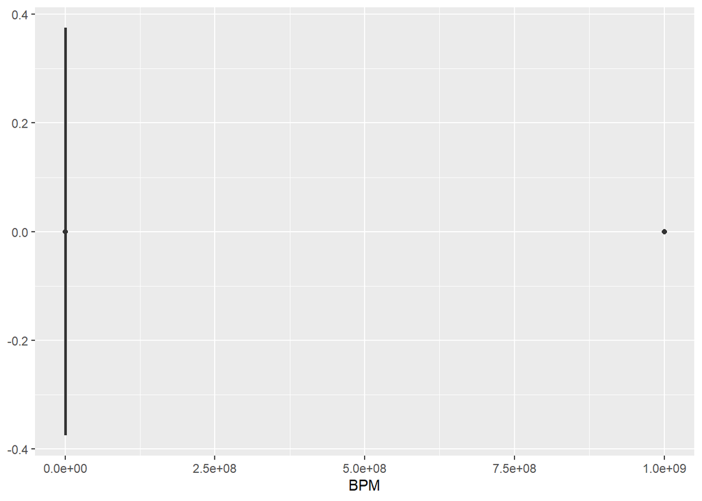

```r
ggplot(mxmh_survey_results,aes(x=BPM))+
  geom_boxplot()
```

```r
mxmh_survey_results %>%
  filter(BPM>1000)
```

```
## # A tibble: 1 × 33
##   Timestamp           Age Primary streaming se…¹ `Hours per day` `While working`
##   <chr>             <dbl> <chr>                            <dbl> <chr>
## 1 9/4/2022 15:41:59    16 Spotify                              7 Yes
## # ℹ abbreviated name: ¹`Primary streaming service`
## # ℹ 28 more variables: Instrumentalist <chr>, Composer <chr>,
## #   `Fav genre` <chr>, Exploratory <chr>, `Foreign languages` <chr>, BPM <dbl>,
## #   `Frequency [Classical]` <chr>, `Frequency [Country]` <chr>,
## #   `Frequency [EDM]` <chr>, `Frequency [Folk]` <chr>,
## #   `Frequency [Gospel]` <chr>, `Frequency [Hip hop]` <chr>,
## #   `Frequency [Jazz]` <chr>, `Frequency [K pop]` <chr>, …
```

```r
is.na(mxmh_survey_results$BPM)<- mxmh_survey_results$BPM > 1000
```

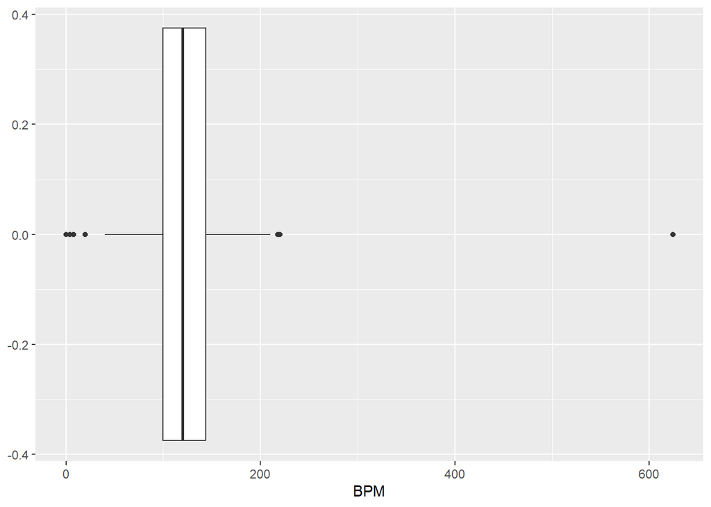

```r
ggplot(mxmh_survey_results,aes(x=BPM))+
  geom_boxplot()
```

#Check for any missing values

```r
colSums(is.na(mxmh_survey_results))
```

```
##                    Timestamp                          Age
##                            0                            1
##    Primary streaming service                Hours per day
##                            1                            0
##                While working              Instrumentalist
##                            3                            4
##                     Composer                    Fav genre
##                            1                            0
##                  Exploratory            Foreign languages
##                            0                            4
##                          BPM        Frequency [Classical]
##                          108                            0
##          Frequency [Country]              Frequency [EDM]
##                            0                            0
##             Frequency [Folk]           Frequency [Gospel]
##                            0                            0
##          Frequency [Hip hop]             Frequency [Jazz]
##                            0                            0
##            Frequency [K pop]            Frequency [Latin]
##                            0                            0
##             Frequency [Lofi]            Frequency [Metal]
##                            0                            0
##              Frequency [Pop]              Frequency [R&B]
##                            0                            0
##              Frequency [Rap]             Frequency [Rock]
##                            0                            0
## Frequency [Video game music]                      Anxiety
##                            0                            0
##                   Depression                     Insomnia
##                            0                            0
##                          OCD                Music effects
##                            0                            8
##                  Permissions
##                            0
```

#Summary stats for quantative variable

```r
summary(mxmh_survey_results[, c("Age", "Hours per day", "BPM",
                                "Anxiety", "Depression", "Insomnia", "OCD")])
```

```
##       Age        Hours per day         BPM           Anxiety
##  Min.   :10.00   Min.   : 0.000   Min.   :  0.0   Min.   : 0.000
##  1st Qu.:18.00   1st Qu.: 2.000   1st Qu.:100.0   1st Qu.: 4.000
##  Median :21.00   Median : 3.000   Median :120.0   Median : 6.000
##  Mean   :25.21   Mean   : 3.573   Mean   :123.4   Mean   : 5.838
##  3rd Qu.:28.00   3rd Qu.: 5.000   3rd Qu.:144.0   3rd Qu.: 8.000
##  Max.   :89.00   Max.   :24.000   Max.   :624.0   Max.   :10.000
##  NA's   :1                        NA's   :108
##    Depression        Insomnia           OCD
##  Min.   : 0.000   Min.   : 0.000   Min.   : 0.000
##  1st Qu.: 2.000   1st Qu.: 1.000   1st Qu.: 0.000
##  Median : 5.000   Median : 3.000   Median : 2.000
##  Mean   : 4.796   Mean   : 3.738   Mean   : 2.637
##  3rd Qu.: 7.000   3rd Qu.: 6.000   3rd Qu.: 5.000
##  Max.   :10.000   Max.   :10.000   Max.   :10.000
##
```

# Distribution of Favorite Genres

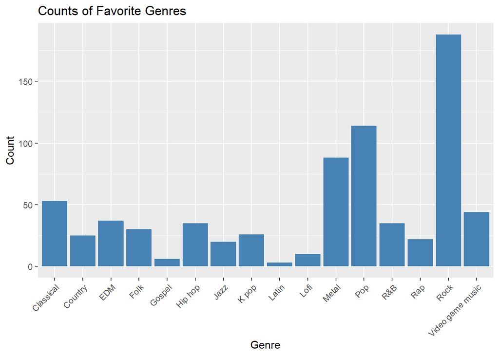

```r
library(ggplot2)

ggplot(mxmh_survey_results, aes(x = `Fav genre`)) +
  geom_bar(fill = "steelblue") +
  labs(title = "Counts of Favorite Genres",
       x = "Genre",
       y = "Count") +
  theme(axis.text.x = element_text(angle = 45, hjust = 1))
```

We can see that rock is the most common favorite genre, followed by Pop and Metal, while Gospel and Latin have the fewest responses.This shows which genres are most popular in the dataset.

# Average Anxiety Score by Genre

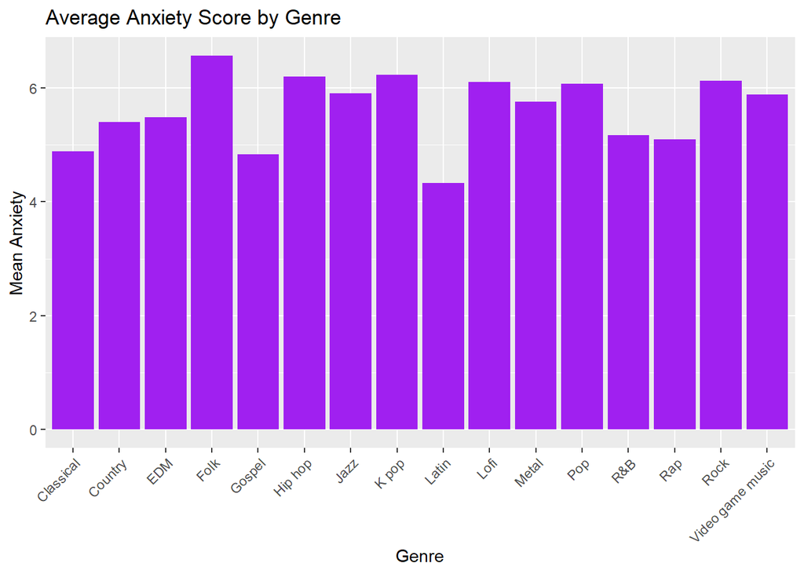

```r
mxmh_survey_results %>%
  group_by(`Fav genre`) %>%
  summarise(mean_anxiety = mean(Anxiety, na.rm = TRUE)) %>%
  ggplot(aes(x = `Fav genre`, y = mean_anxiety)) +
  geom_col(fill = "purple") +
  labs(title = "Average Anxiety Score by Genre",
       x = "Genre",
       y = "Mean Anxiety") +
  theme(axis.text.x = element_text(angle = 45, hjust = 1))
```

Folk listeners reported the highest average anxiety scores, while Latin listeners reported the lowest. This suggests that certain genres may be linked with higher or lower levels of anxiety.

# Depression by Genre

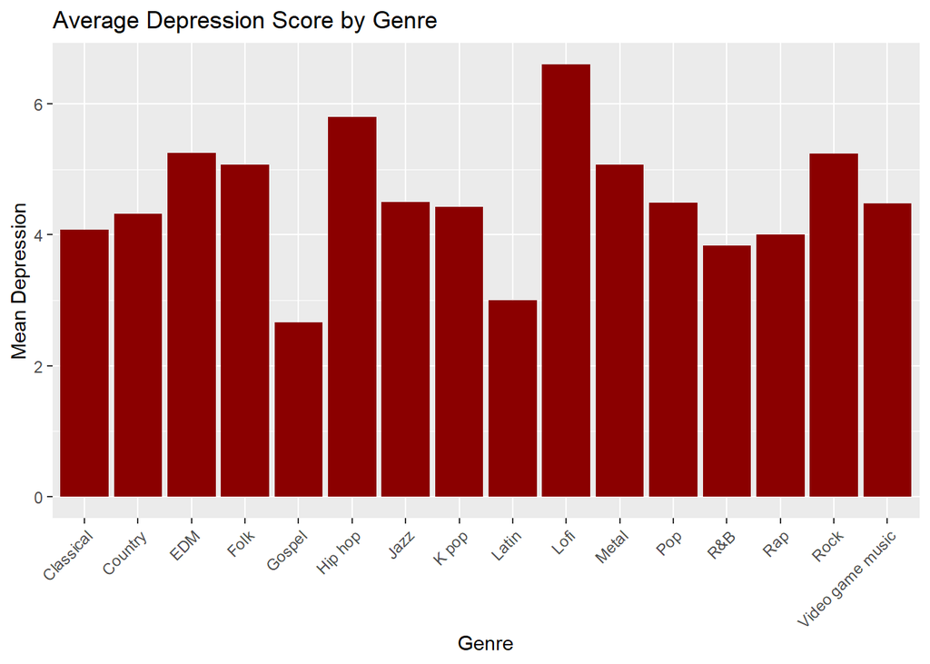

```r
mxmh_survey_results %>%
  group_by(`Fav genre`) %>%
  summarise(mean_depression = mean(Depression, na.rm = TRUE)) %>%
  ggplot(aes(x = `Fav genre`, y = mean_depression)) +
  geom_col(fill = "darkred") +
  labs(title = "Average Depression Score by Genre",
       x = "Genre",
       y = "Mean Depression") +
  theme(axis.text.x = element_text(angle = 45, hjust = 1))
```

This chart shows that lo‑fi, hip hop, and EDM(electronic dance music) listeners report higher average depression scores, while gospel and Latin music listeners report the lowest. The chart suggests certain genres may be linked with higher or lower depression levels.

# Using median instead of mean for the visuals

Anxiety by genre (using meadian)

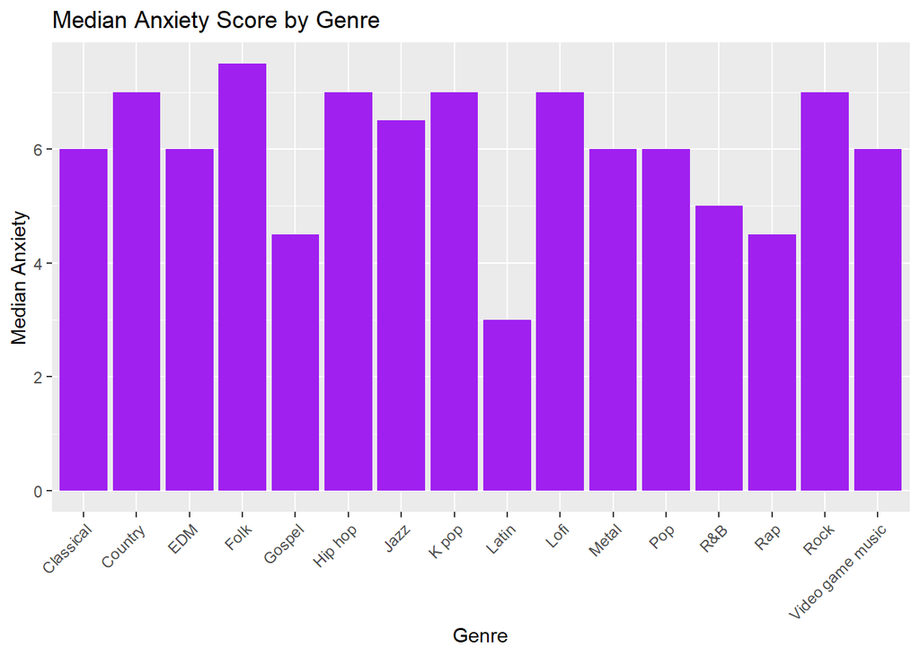

```r
mxmh_survey_results %>%
  group_by(`Fav genre`) %>%
  summarise(median_anxiety = median(Anxiety, na.rm = TRUE)) %>%
  ggplot(aes(x = `Fav genre`, y = median_anxiety)) +
  geom_col(fill = "purple") +
  labs(title = "Median Anxiety Score by Genre",
       x = "Genre",
       y = "Median Anxiety") +
  theme(axis.text.x = element_text(angle = 45, hjust = 1))
```

Using the median instead of the mean gives a clearer picture of the typical listener’s anxiety level, since it reduces the influence of extreme outliers. Compared to the mean chart, small differences appear: genres like Rock and Lofi show higher median anxiety than their mean suggested, while Rap shows lower. This indicates that outliers were affecting the averages, and the median provides a more reliable summary of how anxiety varies across genres.

#Depression by genre (using median)

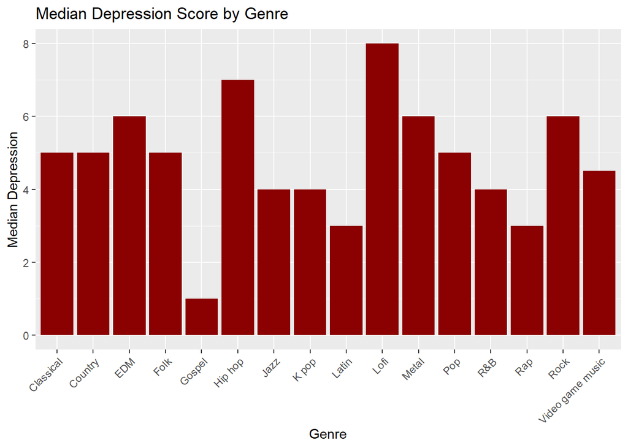

```r
mxmh_survey_results %>%
  group_by(`Fav genre`) %>%
  summarise(median_depression = median(Depression, na.rm = TRUE)) %>%
  ggplot(aes(x = `Fav genre`, y = median_depression)) +
  geom_col(fill = "darkred") +
  labs(title = "Median Depression Score by Genre",
       x = "Genre",
       y = "Median Depression") +
  theme(axis.text.x = element_text(angle = 45, hjust = 1))
```

Switching from mean to median highlights some differences in how genres compare. Lofi listeners show the highest median depression scores, even higher than their mean suggested, while Gospel and Latin remain the lowest. Hip hop stays high, but the median chart makes Lofi stand out more clearly as the top. This shows that extreme values were influencing the averages, and the median provides a more representative summary of typical scores across genres.

#Distributions of Quantative Variables

#Age distribution

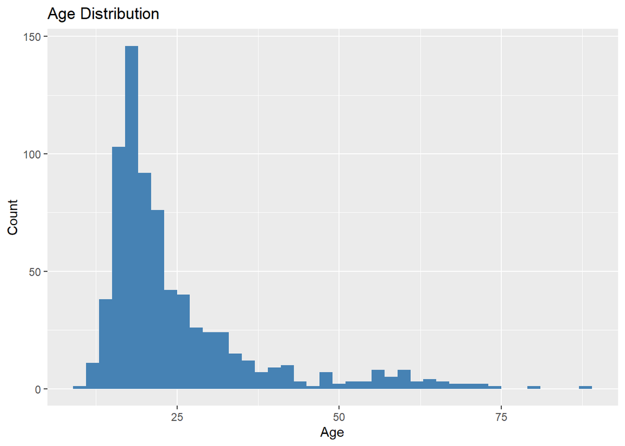

```r
ggplot(mxmh_survey_results, aes(x = Age)) +
  geom_histogram(binwidth = 2, fill = "steelblue") +
  labs(title = "Age Distribution", x = "Age", y = "Count")
```

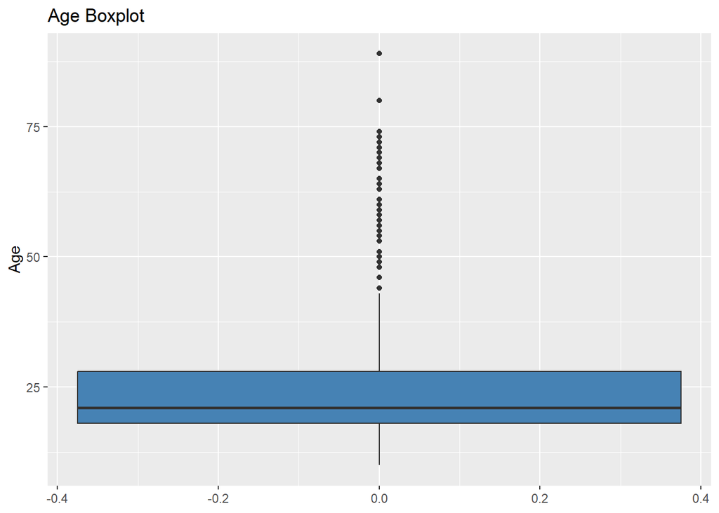

```r
ggplot(mxmh_survey_results, aes(y = Age)) +
  geom_boxplot(fill = "steelblue") +
  labs(title = "Age Boxplot", y = "Age")
```

#Hours per Day Listenting to music

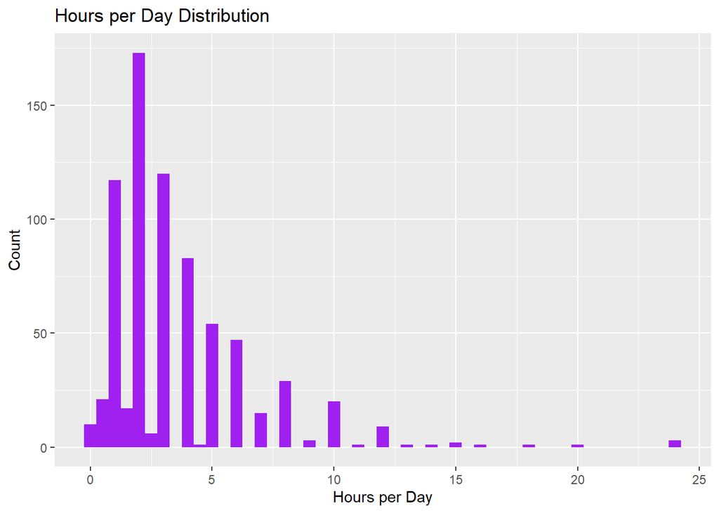

```r
ggplot(mxmh_survey_results, aes(x = `Hours per day`)) +
  geom_histogram(binwidth = 0.5, fill = "purple") +
  labs(title = "Hours per Day Distribution", x = "Hours per Day", y = "Count")
```

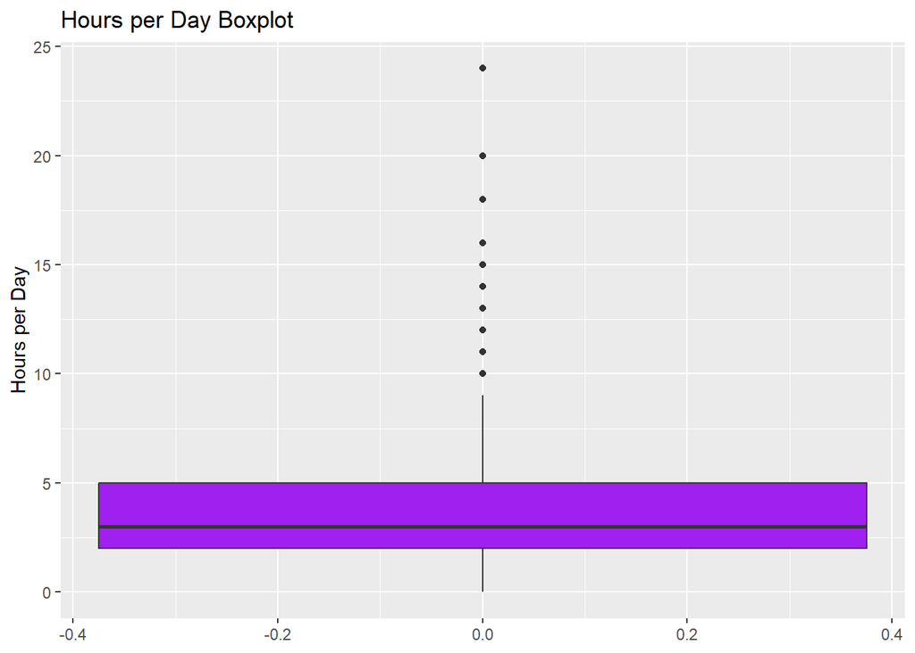

```r
ggplot(mxmh_survey_results, aes(y = `Hours per day`)) +
  geom_boxplot(fill = "purple") +
  labs(title = "Hours per Day Boxplot", y = "Hours per Day")
```

The distribution is right‑skewed, with most participants listening between 1–5 hours daily and a clear peak around 2–3 hours. The boxplot shows the interquartile range centered in this range, with the median near 3 hours. Several extreme outliers appear above 10 hours, extending up to 25, which pull the mean upward compared to the median. This indicates that while typical listening behavior is moderate, a small group of heavy listeners significantly increases the spread.

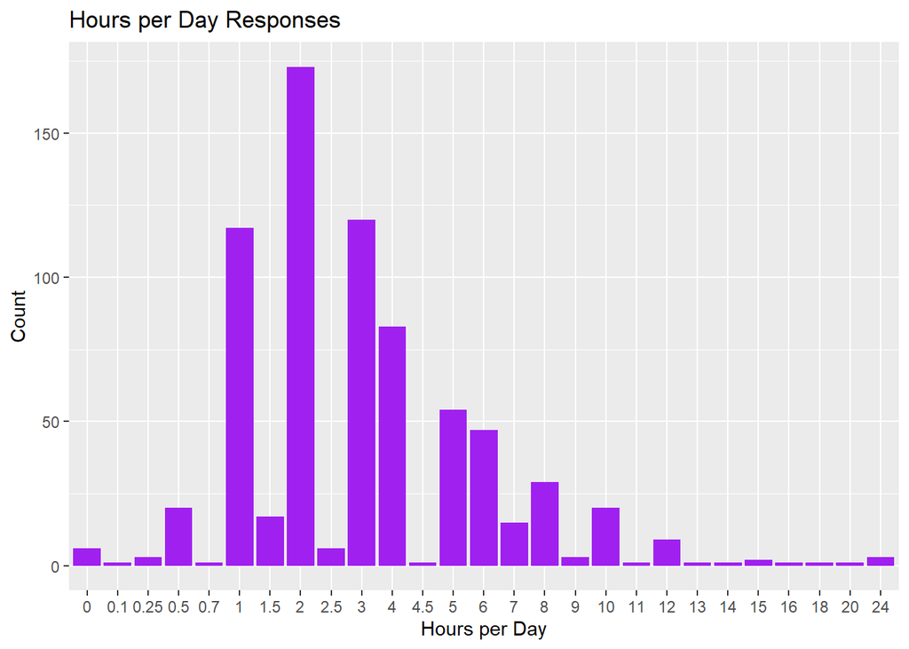

```r
ggplot(mxmh_survey_results,
       aes(x = factor(`Hours per day`))) +
  geom_bar(fill = "purple") +
  labs(title = "Hours per Day Responses",
       x = "Hours per Day",
       y = "Count")
```

The bar chart shows the exact values participants reported for hours spent listening to music each day. Most responses clustered around 1, 2, 3, and 4 hours, with 2 hours being the most common response. The gaps between many decimal values suggest that participants tended to report rounded estimates rather than precise listening times.

#Anxiety Distribution

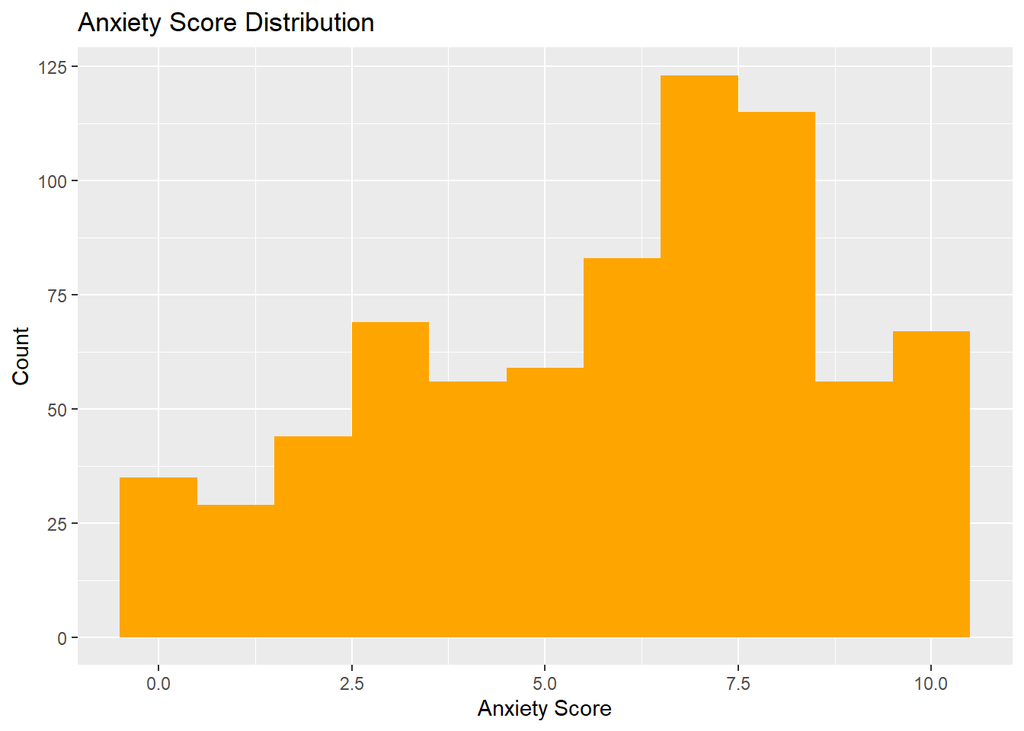

```r
ggplot(mxmh_survey_results, aes(x = Anxiety)) +
  geom_histogram(binwidth = 1, fill = "orange") +
  labs(title = "Anxiety Score Distribution", x = "Anxiety Score", y = "Count")
```

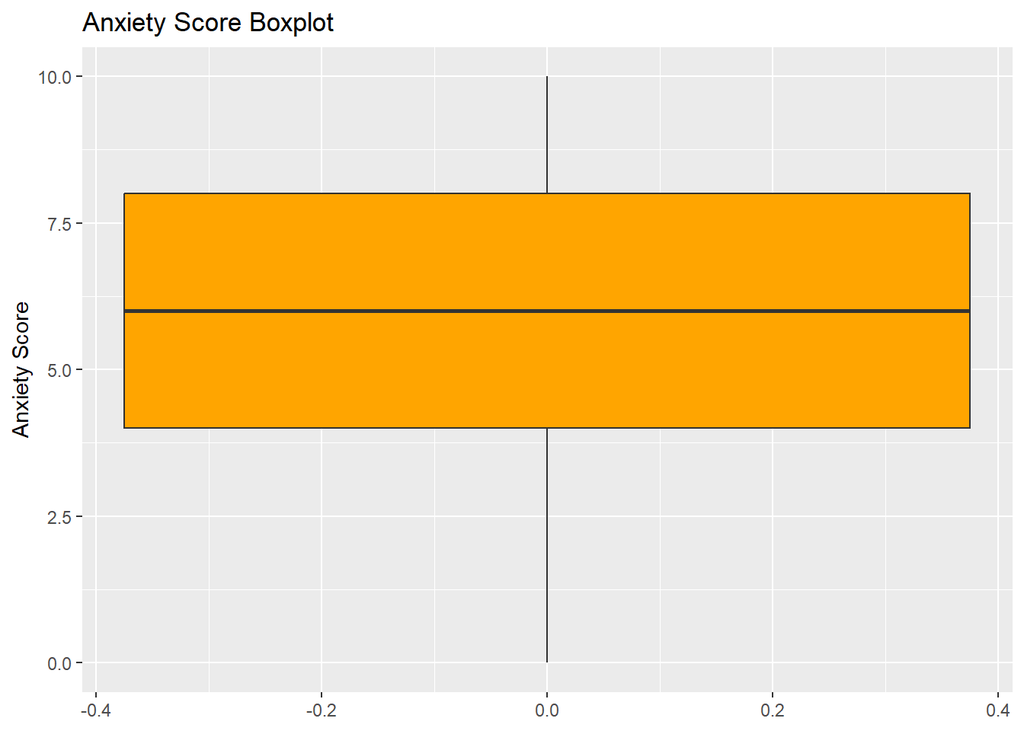

```r
ggplot(mxmh_survey_results, aes(y = Anxiety)) +
  geom_boxplot(fill = "orange") +
  labs(title = "Anxiety Score Boxplot", y = "Anxiety Score")
```

Distribution: The anxiety distribution is left‑skewed, with most participants reporting scores between 6 and 9. The tallest bars appear around 7–8, showing that higher anxiety scores are more common in this dataset. Lower scores (0–3) occur much less frequently, creating a long tail on the left side. This pattern suggests that the sample overall tends toward moderate to high anxiety levels.

Box plot: The boxplot shows the median anxiety score around 6, with the middle 50% of scores (IQR) ranging roughly from 4 to 8. The whiskers extend from 0 to 10, indicating the full range of responses. There are no extreme outliers, but the wide spread shows substantial variability in anxiety levels across participants. The higher concentration of values in the upper quartile aligns with the histogram’s peak around 7–8.

#Depression Distribution

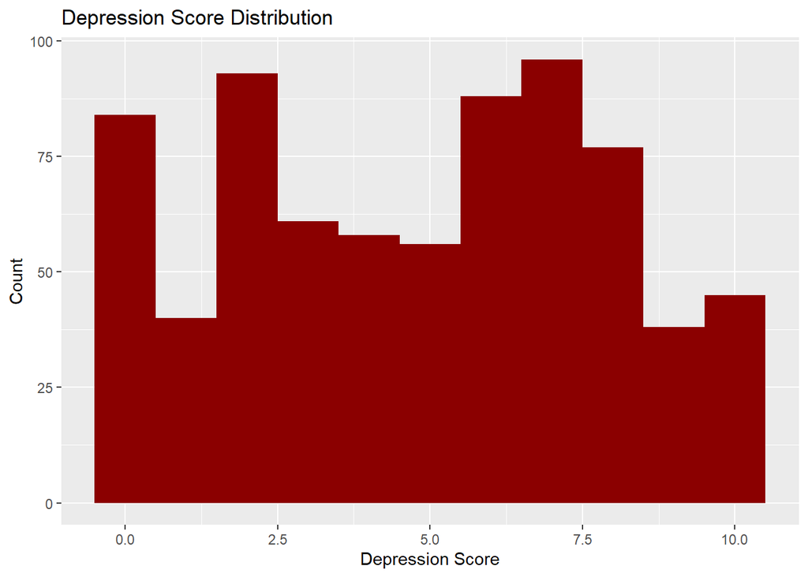

```r
ggplot(mxmh_survey_results, aes(x = Depression)) +
  geom_histogram(binwidth = 1, fill = "darkred") +
  labs(title = "Depression Score Distribution", x = "Depression Score", y = "Count")
```

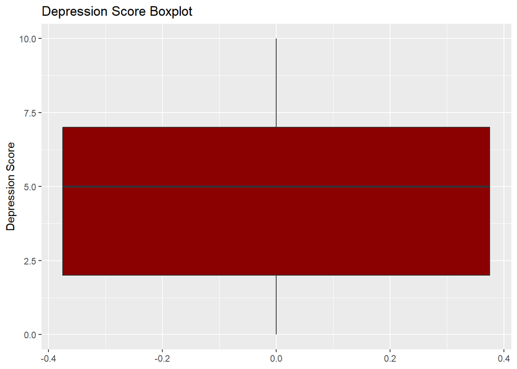

```r
ggplot(mxmh_survey_results, aes(y = Depression)) +
  geom_boxplot(fill = "darkred") +
  labs(title = "Depression Score Boxplot", y = "Depression Score")
```

Distribution: The depression distribution is multi‑modal, meaning it has several peaks rather than one clear dominant range. You can see noticeable clusters around 0–2 and again around 7–8, showing that participants tend to fall into either lower or higher depression score groups. Middle scores (3–5) appear less frequent, creating a dip in the center of the distribution. This pattern suggests the dataset contains two distinct groups: one with low depression symptoms and another with higher levels.

#Insomnia Distribution

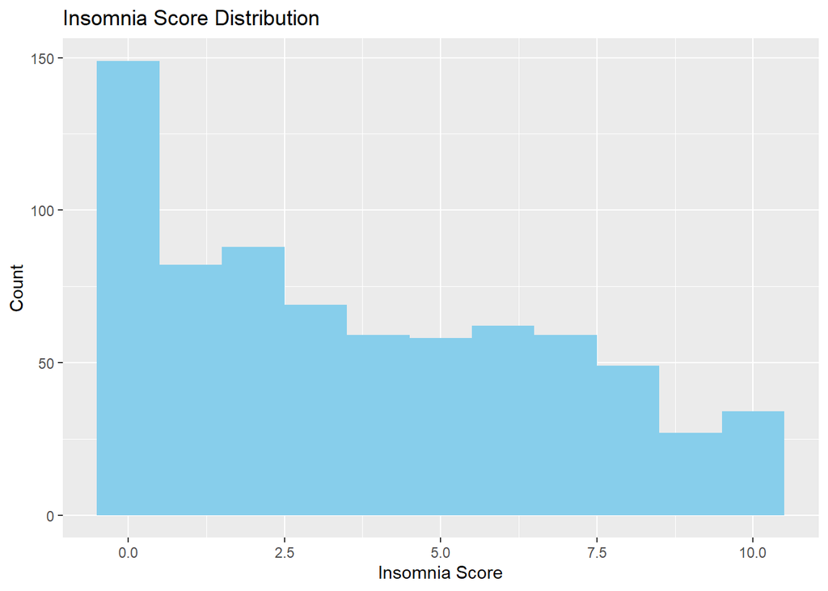

```r
ggplot(mxmh_survey_results, aes(x = Insomnia)) +
  geom_histogram(binwidth = 1, fill = "skyblue") +
  labs(title = "Insomnia Score Distribution", x = "Insomnia Score", y = "Count")
```

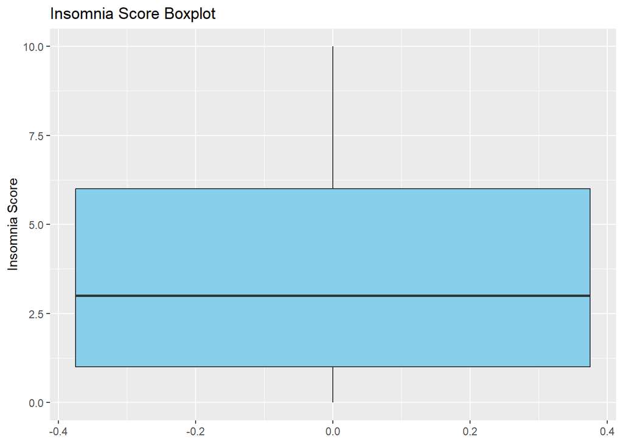

```r
ggplot(mxmh_survey_results, aes(y = Insomnia)) +
  geom_boxplot(fill = "skyblue") +
  labs(title = "Insomnia Score Boxplot", y = "Insomnia Score")
```

Distribution: The insomnia distribution is strongly right‑skewed, with the highest concentration of scores at 0. The count drops steadily as insomnia scores increase, showing that most participants report little to no insomnia symptoms. Higher scores (7–10) appear much less frequently, forming a long tail on the right side. This pattern suggests that insomnia is not widespread in the dataset, but a smaller group of participants experiences more severe symptoms.

Box plot: The boxplot shows the median insomnia score around 3, with the interquartile range stretching from roughly 1 to 6. This indicates moderate variability among participants. The whiskers extend across the full range (0–10), showing that while most scores cluster toward the lower end, the dataset includes individuals with severe insomnia. The combination of a low median and a long right tail aligns with the histogram’s strong right skew.

#OCD Distribution

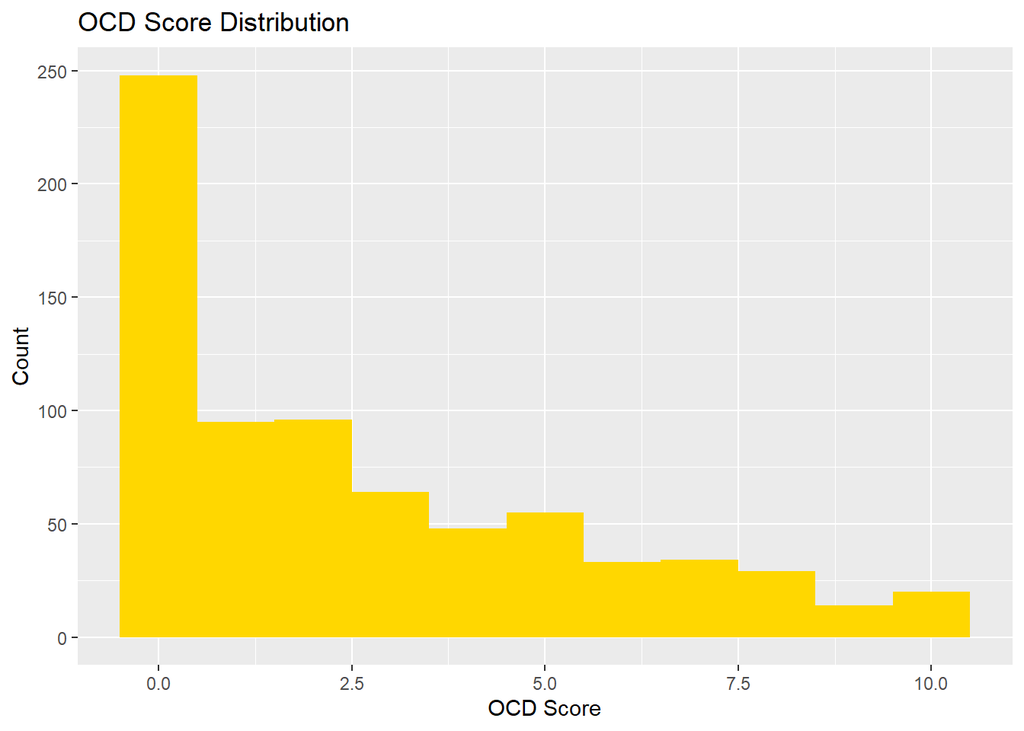

```r
ggplot(mxmh_survey_results, aes(x = OCD)) +
  geom_histogram(binwidth = 1, fill = "gold") +
  labs(title = "OCD Score Distribution", x = "OCD Score", y = "Count")
```

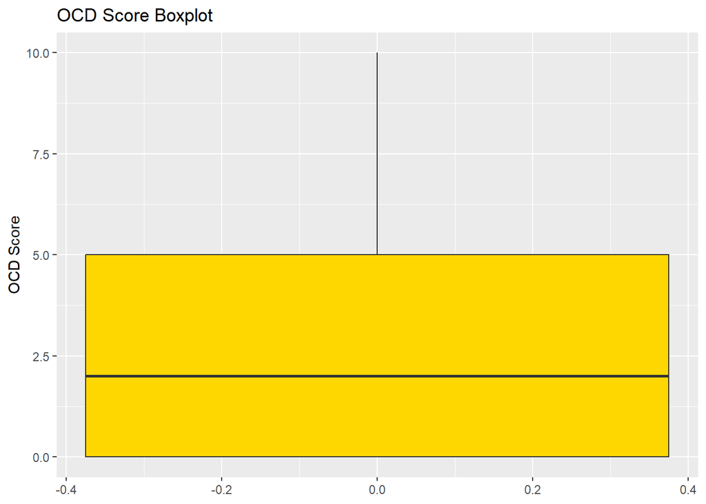

```r
ggplot(mxmh_survey_results, aes(y = OCD)) +
  geom_boxplot(fill = "gold") +
  labs(title = "OCD Score Boxplot", y = "OCD Score")
```

Distribution: The OCD distribution is strongly right‑skewed, with the highest concentration of scores at 0. The count drops sharply as scores increase, showing that most participants report very low OCD symptoms. Higher scores (7–10) occurless frequently, forming a long right tail. This pattern indicates that OCD symptoms are uncommon in the dataset, but a smaller group of participants experiences more severe levels.

Box plot: The boxplot shows the median OCD score around 2, with the interquartile range stretching from roughly 0 to 5. This suggests that half of the participants fall within the low‑to‑moderate range. The whiskers extend across the full range, showing that while most scores cluster toward the lower end, the dataset includes individuals with high OCD scores. The combination of a low median and a long right tail aligns with the histogram’s strong right skew.

#Music effects on mood bar chart

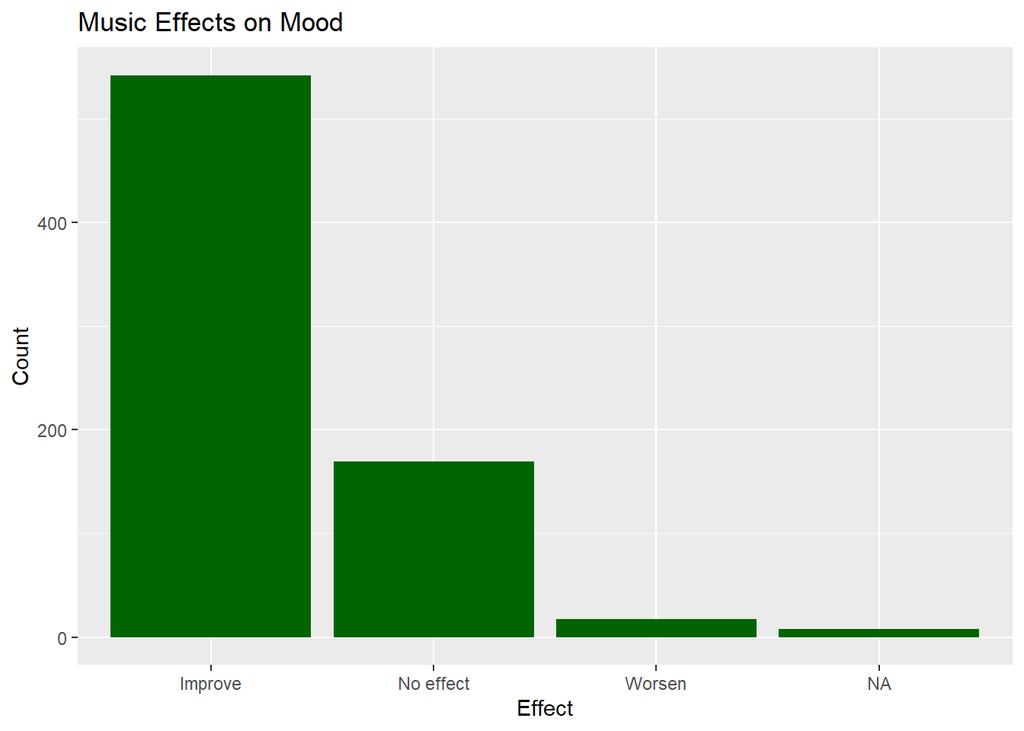

```r
ggplot(mxmh_survey_results, aes(x = `Music effects`)) +
  geom_bar(fill = "darkgreen") +
  labs(title = "Music Effects on Mood",
       x = "Effect",
       y = "Count")
```

Looking at the chart, most participants said music improves their mood, with far fewer reporting no effect or worsened mood. This indicates that overall, music is strongly associated with positive emotional wellbeing.

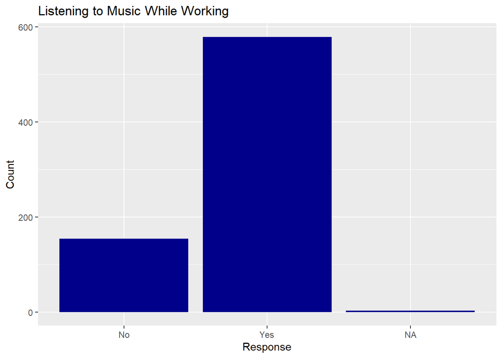

```r
ggplot(mxmh_survey_results, aes(x = `While working`)) +
  geom_bar(fill = "darkblue") +
  labs(title = "Listening to Music While Working",
       x = "Response",
       y = "Count")
```

Most participants reported listening to music while working, with the “Yes” category being the largest group. A smaller portion answered No, and very few responses were missing (NA). This shows a clear preference for using music during tasks, suggesting that music is commonly integrated into work or study routines.

#Anxiety vs Depression by Genre (using median)

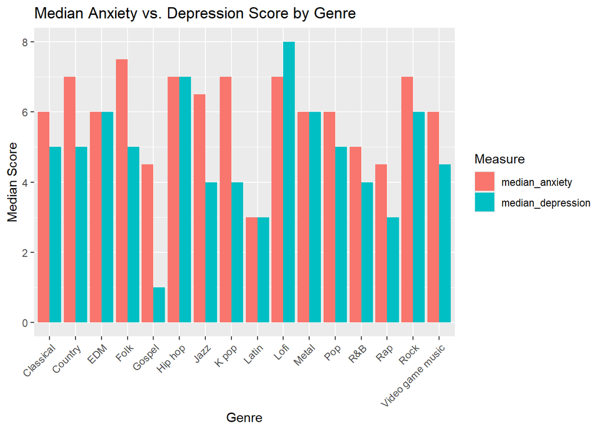

```r
mxmh_survey_results %>%
  group_by(`Fav genre`) %>%
  summarise(
    median_anxiety = median(Anxiety, na.rm = TRUE),
    median_depression = median(Depression, na.rm = TRUE)
  ) %>%
  pivot_longer(cols = c(median_anxiety, median_depression),
               names_to = "Measure",
               values_to = "Score") %>%
  ggplot(aes(x = `Fav genre`, y = Score, fill = Measure)) +
  geom_col(position ="dodge" ) +
  labs(title = "Median Anxiety vs. Depression Score by Genre",
       x = "Genre",
       y = "Median Score") +
  theme(axis.text.x = element_text(angle = 45, hjust = 1))
```

This chart compares median anxiety and depression scores side by side for each genre. It shows that some genres, like Lofi and Hip hop, have high median scores for both measures, while Gospel and Latin remain consistently low. Looking at both together highlights which genres are linked with higher or lower levels of mental health concerns, and using the median ensures the results are more representative of typical listeners rather than being skewed by outliers.

# Looking at center and spread

# Age

```r
median(mxmh_survey_results$Age,
       na.rm = TRUE)
```

```
## [1] 21
```

```r
IQR(mxmh_survey_results$Age,
    na.rm = TRUE)
```

```
## [1] 10
```

The median age is 21 years, meaning half of participants are younger than 21 and half are older. The IQR is 10 years, indicating that the middle 50% of participants span a 10-year age range.

# Hours per day

```r
median(mxmh_survey_results$`Hours per day`,
       na.rm = TRUE)
```

```
## [1] 3
```

```r
IQR(mxmh_survey_results$`Hours per day`,
    na.rm = TRUE)
```

```
## [1] 3
```

The median listening time is 3 hours per day. The IQR is 3 hours, indicating that the middle 50% of participants differ by about 3 hours of listening time.

# Anxiety

```r
median(mxmh_survey_results$Anxiety,
       na.rm = TRUE)
```

```
## [1] 6
```

```r
IQR(mxmh_survey_results$Anxiety,
    na.rm = TRUE)
```

```
## [1] 4
```

The median anxiety score is 6. The IQR is 4, indicating that anxiety scores vary by about 4 points across the middle 50% of participants.

# Insomnia

```r
median(mxmh_survey_results$Insomnia,
na.rm = TRUE)
```

```
## [1] 3
```

```r
IQR(mxmh_survey_results$Insomnia,
na.rm = TRUE)
```

```
## [1] 5
```

The median insomnia score is 3, meaning half of participants scored below 3 and half scored above 3. The IQR is 5, indicating that the middle 50% of participants insomnia scores span 5 points.

# OCD

```r
median(mxmh_survey_results$OCD,
       na.rm = TRUE)
```

```
## [1] 2
```

```r
IQR(mxmh_survey_results$OCD,
    na.rm = TRUE)
```

```
## [1] 5
```

The median OCD score is 2, meaning half of participants scored below 2 and half scored above 2. The IQR is 5, indicating that the middle 50% of participants’ OCD scores span 5 points.

#Depression

```r
mean(mxmh_survey_results$Depression,
     na.rm = TRUE)
```

```
## [1] 4.796196
```

```r
sd(mxmh_survey_results$Depression,
   na.rm = TRUE)
```

```
## [1] 3.02887
```

Since the depression distribution appeared multimodal, the mean and standard deviation provide an additional way to summarize the data. The mean depression score was 4.80, indicating that participants reported moderate levels of depression on average. The standard deviation was 3.03, showing that depression scores varied considerably across participants, which is consistent with the multiple clusters observed in the histogram.

#Looking at correlations

#Anxiety and Insomnia

```r
cor(mxmh_survey_results$Anxiety,
    mxmh_survey_results$Insomnia,
    use="complete.obs")
```

```
## [1] 0.2926694
```

The correlation between anxiety and insomnia was 0.29, indicating a weak relationship. Participants with higher anxiety scores tended to report slightly higher insomnia scores.

#Anxiety and depression

```r
cor(mxmh_survey_results$Anxiety,
    mxmh_survey_results$Depression,
    use = "complete.obs")
```

```
## [1] 0.5199695
```

The correlation between anxiety and depression was 0.52, indicating a moderate positive relationship. This suggests that participants with higher anxiety scores also tended to report higher depression scores.

#Depression and Insomnia

```r
cor(mxmh_survey_results$Depression,
    mxmh_survey_results$Insomnia,
    use = "complete.obs")
```

```
## [1] 0.3789964
```

The correlation between depression and insomnia was 0.38, indicating a weak to moderate positive relationship. Participants with higher depression scores tended to report higher insomnia scores, although the relationship was not as strong as the relationship between anxiety and depression.

#Depression and OCD

```r
cor(mxmh_survey_results$Depression,
    mxmh_survey_results$OCD,
    use="complete.obs")
```

```
## [1] 0.196988
```

The correlation between depression and OCD was 0.20, indicating a weak positive relationship. Participants with higher depression scores were slightly more likely to report higher OCD scores, but the relationship was relatively small compared to the other mental health variables examined.